# Assignment 2

Tiana Lee

12 Mar 2024

**All Materials Needed**

These are all the packages and data sets that are needed for this assignment. They will be installed if the packages are not present.

```r
if(!requireNamespace("GEOquery", quietly = TRUE)){
  tidyr::install("GEOquery")
}
```

```
## Setting options('download.file.method.GEOquery'='auto')
```

```
## Setting options('GEOquery.inmemory.gpl'=FALSE)
```

```r
library(GEOquery)
if(!requireNamespace("readr", quietly = TRUE)){
  tidyr::install("readr")
}

library(readr)

if(!requireNamespace("dplyr", quietly = TRUE)) {
  tidyr::install("dplyr")
}

library(dplyr)
if(!requireNamespace("knitr", quietly = TRUE)){
  tidyr::install("knitr")
}

library(knitr)

if(!requireNamespace("DESeq2", quietly = TRUE)) {
  tidyr::install("DESeq2")
}

library(DESeq2)
if(!requireNamespace("edgeR", quietly = TRUE)) {
  tidyr::install("edgeR")
}

library(edgeR)
```

```r
if(!requireNamespace("ggplot2", quietly = TRUE)){
  tidyr::install("ggplot2")
}

library(ggplot2)

if(!requireNamespace("ComplexHeatmap", quietly = TRUE)){
  tidyr::install("ComplexHeatmap")
}

library(ComplexHeatmap)
if(!requireNamespace("circlize", quietly = TRUE)){
  tidyr::install("circlize")
}

library(circlize)
library(gprofiler2)
```

This is the raw dataset.

```r
geo_id <- "GSE242722"
gse <- getGEO(geo_id, GSEMatrix=FALSE)
```

```
## Reading file....
```

```
## Parsing....
```

[output not shown]

```
## GPL20301 (1 of 14 entities)
```

```
## GSM7767639 (2 of 14 entities)
```

```
## GSM7767640 (3 of 14 entities)
```

```
## GSM7767641 (4 of 14 entities)
```

```
## GSM7767642 (5 of 14 entities)
```

```
## GSM7767643 (6 of 14 entities)
```

```
## GSM7767644 (7 of 14 entities)
```

```
## GSM7767645 (8 of 14 entities)
```

```
## GSM7767646 (9 of 14 entities)
```

```
## GSM7767647 (10 of 14 entities)
```

```
## GSM7767648 (11 of 14 entities)
```

```
## GSM7767649 (12 of 14 entities)
```

```
## GSM7767650 (13 of 14 entities)
```

```r
geo_filename <- getGEOSuppFiles(geo_id, fetch_files = FALSE)

geo_filename$fname
```

```
## [1] "GSE242722_Raw_counts_of_sequencing_reads_for_genes.csv.gz"
```

```r
data_filename <- geo_filename$fname[1]

download_geofile <- file.path(getwd()) #download and stores files
```

This is the dataset that was mapped and normalized from the last assignment [A1](https://github.com/bcb420-2024/Tiana_Lee/blob/main/A1_TianaLee.html).

```r
norm_data <- read_rds("~/projects/normalized_counts.rds")
norm_data <- DGEList(norm_data)

norm_data
```

```
## An object of class "DGEList"
## $counts
##            clean_data$NHBED1 clean_data$NHBED2 clean_data$NHBEP1
## WASH7P             2.0404668         2.0207342         4.1625467
## AL627309.6         0.1200275         0.2405636         0.4428241
## FO538757.1         3.1807277         3.4160031         4.0296995
## MTND2P28           4.7410847         3.0792141         5.0481950
## MTCO1P12          15.6635837         9.3338676        13.5947005
##            clean_data$NHBEP2 clean_data$NHBEU1 clean_data$NHBEU2
## WASH7P             3.4042825          5.685337         3.9263453
## AL627309.6         0.5305375          1.071826         0.7095805
## FO538757.1         4.5095691          5.825141         3.1221541
## MTND2P28           4.7306264          4.194101         6.2443081
## MTCO1P12          11.9370946         12.722107        14.4754415
##            clean_data$NHBEU3 clean_data$NHBEU4
## WASH7P              4.119754          3.825121
## AL627309.6          0.720957          1.017319
## FO538757.1          5.613165          6.470152
## MTND2P28            4.016760          4.923826
## MTCO1P12            9.526931          7.853706
## 15165 more rows ...
##
## $samples
##                   group  lib.size norm.factors
## clean_data$NHBED1     1 1065165.9            1
## clean_data$NHBED2     1  920827.1            1
## clean_data$NHBEP1     1  993097.6            1
## clean_data$NHBEP2     1  990361.7            1
## clean_data$NHBEU1     1  919132.6            1
## clean_data$NHBEU2     1  979035.3            1
## clean_data$NHBEU3     1 1199280.0            1
## clean_data$NHBEU4     1  960554.1            1
```

*Background*

Hospitalization rates have been a underlying problem with the COVID pandemic. This paper focused on the lung damage that patients get from severe covid cases. Looking into this was of interest to them since it would be able to allow them to suggest therapeutic intervention tactics that could possible work better than the current solutions. Although there are current solutions, they do not often work in these severe hospitalization cases which this paper tries to address why that might be the case by chasing a current hypothesis that the diseased lung might have problems regulating coagulation and thrombosis which were found in patient samples previously. To find their answers, they did proteomic and gene analysis on a few different cell types.

From [A1](https://github.com/bcb420-2024/Tiana_Lee/blob/main/A1_TianaLee.html) we were able to normalize the dataset in the paper. To make analysis easier, one set of cell types were excluded from the analysis (NHBE was only used).

**Differential Expression Test**

Calculating p-values for each of genes in the expression set. This is done to figure out which are statistically differentially expressed.

```r
# form the groups
group <- factor(c(1,1,1,1,0,0,0,0))
model_design <- model.matrix(~group)
model_design
```

```
##   (Intercept) group1
## 1           1      1
## 2           1      1
## 3           1      1
## 4           1      1
## 5           1      0
## 6           1      0
## 7           1      0
## 8           1      0
## attr(,"assign")
## [1] 0 1
## attr(,"contrasts")
## attr(,"contrasts")$group
## [1] "contr.treatment"
```

```r
dispersion <- estimateDisp(norm_data, model_design)

fit <- glmFit(dispersion)

diffexpr <- glmLRT(fit)

pval <- topTags(diffexpr, sort.by = "PValue", n = nrow(norm_data))

length(which(pval$table$PValue < 0.05))  #This is the number of differentially expressed values
```

```
## [1] 650
```

```r
length(which(pval$table$PValue < 0.0001))  #This is the number of differentially expressed values
```

```
## [1] 7
```

Table 1. Table of genes sorted in order of increasing p-values.

Multiple hypothesis testing was done to correct p-values using the FDR values.

```r
length(which(pval$table$FDR < 0.05))  #This is the number of genes that passed the correction
```

```
## [1] 5
```

```r
length(which(pval$table$FDR < 0.0001))  #This is the number of genes that passed the correction
```

```
## [1] 0
```

*What thresholds did you use and why?* I used a threshold of 0.05 since it seems to be the standard used throughout. I could also try setting is a lot smaller to mimick what the paper did at 0.0001 but I am not sure if this is the best course of action since they were looking at 2 different cell lines with 2 different control whereas I am only looking at 1 set of cell lines.

*Which method did you use? And Why? How many genes passed correction?* I used the FDR value. This is because it typically gives you the ratio of false predictions over total predictions which indicates how many are truly null which will account for the type 1 error. 5 genes were significantly expressed for a FDR value < 0.05 and 0 were significantly expressed for a FDR value < 0.0001.

Creating a volcano plot of differentially expressed genes.

```r
tmp <- pval$table
tmp
```

|  | logFC | logCPM | LR | PValue | FDR |
| --- | --- | --- | --- | --- | --- |
| MX1 | 1.85627292 | 3.645130 | 23.6144964 | 1.176975e-06 | 0.01785471 |
| OAS2 | 1.76645319 | 4.877700 | 20.7552565 | 5.218813e-06 | 0.03958470 |
| IFI44 | 2.00135079 | 3.059040 | 19.4982344 | 1.006927e-05 | 0.04095509 |
| TF | 2.25861179 | 5.604145 | 19.3646133 | 1.079897e-05 | 0.04095509 |
| IFIT1 | 2.57921312 | 3.882147 | 18.8154613 | 1.439951e-05 | 0.04368811 |
| OAS1 | 1.67721325 | 3.709839 | 17.1679625 | 3.421585e-05 | 0.08650907 |
| IFIT3 | 1.83335144 | 3.878458 | 15.7027412 | 7.411668e-05 | 0.16062143 |
| ISG15 | 1.81914963 | 5.118486 | 14.4873177 | 1.411063e-04 | 0.26757292 |
| IFITM1 | 1.28859438 | 4.435157 | 12.7232396 | 3.611396e-04 | 0.60872093 |
| NNMT | -4.15366092 | 3.772461 | 12.3511062 | 4.407252e-04 | 0.62913177 |

[output cut: 9990 more lines]

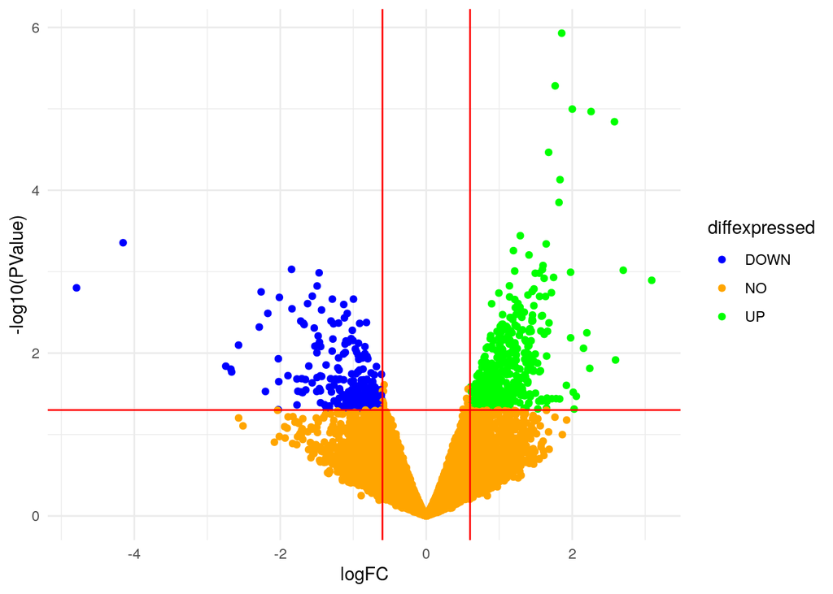

```r
tab <- tmp[complete.cases(tmp), ]

tab$diffexpressed <- "NO"
tab$diffexpressed[tab$logFC > 0.6 & tab$PValue < 0.05] <- "UP"
tab$diffexpressed[tab$logFC < -0.6 & tab$PValue < 0.05] <- "DOWN"

p <- ggplot(data=tab, aes(x=logFC, y=-log10(PValue), col=diffexpressed)) + geom_point() + theme_minimal()
p2 <- p + geom_vline(xintercept=c(-0.6, 0.6), col="red") +
        geom_hline(yintercept=-log10(0.05), col="red")
p3 <- p2 + scale_color_manual(values=c("blue", "grey", "orange"))
mycolors <- c("blue", "orange", "purple")
names(mycolors) <- c("DOWN", "UP", "NO")
p3 <- p2 + scale_colour_manual(values = mycolors)

ggplot(data=tab, aes(x=logFC, y=-log10(PValue), col=diffexpressed)) +
        geom_point() +
        theme_minimal() +
        scale_color_manual(values=c("blue", "orange", "green")) +
        geom_vline(xintercept=c(-0.6, 0.6), col="red") +
        geom_hline(yintercept=-log10(0.05), col="red")
```

Figure 1. Volcano plot of up/downregulated description. Genes of interest are highlighted in blue for down regulated and green for upregulated

Visualization using a heatmap.

[figure not shown]

```r
heatmap_matrix <- pval$table
top_fdr <- rownames(heatmap_matrix$table[heatmap_matrix$table$FDR < 0.05,])

heatmapm_tophits <- t(scale(t(heatmap_matrix[which(rownames(norm_data) %in% top_fdr),])))

if(min(heatmapm_tophits) < 0){colscale <- colorRamp2(c(min(heatmapm_tophits),
                                                       0, max(heatmapm_tophits)),
                                                     c("lavender", "grey", "yellow"))} else {
                                                       colscale <- colorRamp2(c(min(heatmapm_tophits),
                                                                                max(heatmapm_tophits)),
                                                                              c("lavender", "pink"))
                                                     }
heat_map <- Heatmap(as.matrix(heatmapm_tophits), col=heatmap_col,
              row_names_gp = gpar(fontsize=8), column_names_gp = gpar(fontsize=10),
              heatmap_legend_param = list(title="Normalized log2FC"))

heat_map
```

**Thresholded Over-representation Analysis**

G:profiler was used to do the over-representation analysis of all differentially expressed genes.

```r
upreg_id <- which(pval$table$FDR < 0.05 &
                  pval$table$logFC > 0)
downreg_id <- which(pval$table$FDR < 0.01 &
                    pval$table$logFC < 0)

# names of upregulated genes
upreg <- pval$table[upreg_id,]
upreg_list <- rownames(upreg)

# names of downregulated genes
downreg <- pval$table[downreg_id,]
downreg_list <- rownames(downreg)

#actual analysis
go_all <-  gost(query = c(upreg_list, downreg_list),
                organism = "hsapiens",
                correction_method = "fdr",
                domain_scope = "annotated",
                numeric_ns = "", sources = c("GO:BP", "REAC", "WP"))

go_all200 <- go_all$result[which(go_all$result$term_size <= 200),]

go_all200
```

|  | query | significant | p_value | term_size | query_size | intersection_size | precision | recall | term_id | source | term_name | effective_domain_size | source_order | parents |
| --- | --- | --- | --- | --- | --- | --- | --- | --- | --- | --- | --- | --- | --- | --- |
| 1 | query_1 | TRUE | 4.350358e-05 | 95 | 5 | 3 | 0.60 | 0.03157895 | GO:0048525 | GO:BP | negative regulation of viral process | 21031 | 13233 |  |
| 2 | query_1 | TRUE | 4.350358e-05 | 85 | 5 | 3 | 0.60 | 0.03529412 | GO:0045069 | GO:BP | regulation of viral genome replication | 21031 | 11656 |  |
| 4 | query_1 | TRUE | 4.350358e-05 | 7 | 5 | 2 | 0.40 | 0.28571429 | GO:0070106 | GO:BP | interleukin-27-mediated signaling pathway | 21031 | 16412 |  |
| 5 | query_1 | TRUE | 4.350358e-05 | 88 | 5 | 3 | 0.60 | 0.03409091 | GO:0034340 | GO:BP | response to type I interferon | 21031 | 8869 |  |
| 6 | query_1 | TRUE | 4.350358e-05 | 55 | 5 | 3 | 0.60 | 0.05454545 | GO:0045071 | GO:BP | negative regulation of viral genome replication | 21031 | 11658 |  |
| 10 | query_1 | TRUE | 6.668292e-05 | 128 | 5 | 3 | 0.60 | 0.02343750 | GO:0019079 | GO:BP | viral genome replication | 21031 | 5752 |  |
| 11 | query_1 | TRUE | 7.944729e-05 | 145 | 5 | 3 | 0.60 | 0.02068966 | GO:1903900 | GO:BP | regulation of viral life cycle | 21031 | 23972 |  |
| 13 | query_1 | TRUE | 1.065680e-04 | 169 | 5 | 3 | 0.60 | 0.01775148 | GO:0050792 | GO:BP | regulation of viral process | 21031 | 13689 |  |
| 21 | query_1 | TRUE | 7.515004e-04 | 51 | 5 | 2 | 0.40 | 0.03921569 | GO:0140374 | GO:BP | antiviral innate immune response | 21031 | 20319 |  |
| 23 | query_1 | TRUE | 1.781956e-03 | 82 | 5 | 2 | 0.40 | 0.02439024 | GO:0071357 | GO:BP | cellular response to type I interferon | 21031 | 17109 |  |

[output cut: 31 more lines]

```r
kable(go_all200)
```

|  | query | significant | p_value | term_size | query_size | intersection_size | precision | recall | term_id | source | term_name | effective_domain_size | source_order | parents |
| --- | --- | --- | --- | --- | --- | --- | --- | --- | --- | --- | --- | --- | --- | --- |
| 1 | query_1 | TRUE | 0.0000435 | 95 | 5 | 3 | 0.60 | 0.0315789 | GO:0048525 | GO:BP | negative regulation of viral process | 21031 | 13233 | GO:00160…. |
| 2 | query_1 | TRUE | 0.0000435 | 85 | 5 | 3 | 0.60 | 0.0352941 | GO:0045069 | GO:BP | regulation of viral genome replication | 21031 | 11656 | GO:00190…. |
| 4 | query_1 | TRUE | 0.0000435 | 7 | 5 | 2 | 0.40 | 0.2857143 | GO:0070106 | GO:BP | interleukin-27-mediated signaling pathway | 21031 | 16412 | GO:0019221 |
| 5 | query_1 | TRUE | 0.0000435 | 88 | 5 | 3 | 0.60 | 0.0340909 | GO:0034340 | GO:BP | response to type I interferon | 21031 | 8869 | GO:00340…. |
| 6 | query_1 | TRUE | 0.0000435 | 55 | 5 | 3 | 0.60 | 0.0545455 | GO:0045071 | GO:BP | negative regulation of viral genome replication | 21031 | 11658 | GO:00190…. |
| 10 | query_1 | TRUE | 0.0000667 | 128 | 5 | 3 | 0.60 | 0.0234375 | GO:0019079 | GO:BP | viral genome replication | 21031 | 5752 | GO:00160…. |
| 11 | query_1 | TRUE | 0.0000794 | 145 | 5 | 3 | 0.60 | 0.0206897 | GO:1903900 | GO:BP | regulation of viral life cycle | 21031 | 23972 | GO:00190…. |
| 13 | query_1 | TRUE | 0.0001066 | 169 | 5 | 3 | 0.60 | 0.0177515 | GO:0050792 | GO:BP | regulation of viral process | 21031 | 13689 | GO:00160…. |
| 21 | query_1 | TRUE | 0.0007515 | 51 | 5 | 2 | 0.40 | 0.0392157 | GO:0140374 | GO:BP | antiviral innate immune response | 21031 | 20319 | GO:00450…. |
| 23 | query_1 | TRUE | 0.0017820 | 82 | 5 | 2 | 0.40 | 0.0243902 | GO:0071357 | GO:BP | cellular response to type I interferon | 21031 | 17109 | GO:00343…. |
| 26 | query_1 | TRUE | 0.0048425 | 2 | 5 | 1 | 0.20 | 0.5000000 | GO:0030581 | GO:BP | symbiont intracellular protein transport in host | 21031 | 7088 | GO:00150…. |
| 27 | query_1 | TRUE | 0.0048425 | 2 | 5 | 1 | 0.20 | 0.5000000 | GO:0019060 | GO:BP | intracellular transport of viral protein in host cell | 21031 | 5738 | GO:00305…. |
| 29 | query_1 | TRUE | 0.0067621 | 3 | 5 | 1 | 0.20 | 0.3333333 | GO:1903487 | GO:BP | regulation of lactation | 21031 | 23632 | GO:00075…. |
| 33 | query_1 | TRUE | 0.0099022 | 5 | 5 | 1 | 0.20 | 0.2000000 | GO:0051097 | GO:BP | negative regulation of helicase activity | 21031 | 13931 | GO:00327…. |
| 34 | query_1 | TRUE | 0.0130685 | 7 | 5 | 1 | 0.20 | 0.1428571 | GO:0071281 | GO:BP | cellular response to iron ion | 21031 | 17037 | GO:00100…. |
| 35 | query_1 | TRUE | 0.0130685 | 7 | 5 | 1 | 0.20 | 0.1428571 | GO:0034756 | GO:BP | regulation of iron ion transport | 21031 | 9027 | GO:00068…. |
| 36 | query_1 | TRUE | 0.0145191 | 8 | 5 | 1 | 0.20 | 0.1250000 | GO:0046719 | GO:BP | regulation by virus of viral protein levels in host cell | 21031 | 12747 | GO:00507…. |
| 38 | query_1 | TRUE | 0.0206246 | 12 | 5 | 1 | 0.20 | 0.0833333 | GO:0051095 | GO:BP | regulation of helicase activity | 21031 | 13929 | GO:00434…. |
| 39 | query_1 | TRUE | 0.0301265 | 18 | 5 | 1 | 0.20 | 0.0555556 | GO:0071360 | GO:BP | cellular response to exogenous dsRNA | 21031 | 17112 | GO:00433…. |
| 40 | query_1 | TRUE | 0.0310022 | 19 | 5 | 1 | 0.20 | 0.0526316 | GO:0032780 | GO:BP | negative regulation of ATP-dependent activity | 21031 | 8095 | GO:00434…. |
| 41 | query_1 | TRUE | 0.0315032 | 20 | 5 | 1 | 0.20 | 0.0500000 | GO:0045780 | GO:BP | positive regulation of bone resorption | 21031 | 12010 | GO:00451…. |
| 45 | query_1 | TRUE | 0.0347930 | 24 | 5 | 1 | 0.20 | 0.0416667 | GO:0071359 | GO:BP | cellular response to dsRNA | 21031 | 17111 | GO:00433…. |
| 46 | query_1 | TRUE | 0.0411080 | 29 | 5 | 1 | 0.20 | 0.0344828 | GO:0010039 | GO:BP | response to iron ion | 21031 | 3889 | GO:0010038 |
| 48 | query_1 | TRUE | 0.0421041 | 31 | 5 | 1 | 0.20 | 0.0322581 | GO:0045070 | GO:BP | positive regulation of viral genome replication | 21031 | 11657 | GO:00190…. |
| 49 | query_1 | TRUE | 0.0000171 | 71 | 4 | 3 | 0.75 | 0.0422535 | REAC:R-HSA-909733 | REAC | Interferon alpha/beta signaling | 10842 | 1194 | REAC:R-H…. |
| 50 | query_1 | TRUE | 0.0000171 | 78 | 4 | 3 | 0.75 | 0.0384615 | REAC:R-HSA-1169410 | REAC | Antiviral mechanism by IFN-stimulated genes | 10842 | 152 | REAC:R-H…. |
| 51 | query_1 | TRUE | 0.0001754 | 193 | 4 | 3 | 0.75 | 0.0155440 | REAC:R-HSA-913531 | REAC | Interferon Signaling | 10842 | 1193 | REAC:R-H…. |
| 52 | query_1 | TRUE | 0.0014670 | 70 | 4 | 2 | 0.50 | 0.0285714 | REAC:R-HSA-1169408 | REAC | ISG15 antiviral mechanism | 10842 | 1132 | REAC:R-H…. |
| 54 | query_1 | TRUE | 0.0132670 | 9 | 4 | 1 | 0.25 | 0.1111111 | REAC:R-HSA-8983711 | REAC | OAS antiviral response | 10842 | 1586 | REAC:R-H…. |
| 55 | query_1 | TRUE | 0.0390501 | 31 | 4 | 1 | 0.25 | 0.0322581 | REAC:R-HSA-917977 | REAC | Transferrin endocytosis and recycling | 10842 | 2487 | REAC:R-H…. |
| 57 | query_1 | TRUE | 0.0003019 | 22 | 4 | 2 | 0.50 | 0.0909091 | WP:WP4197 | WP | Immune response to tuberculosis | 8286 | 358 | WP:000000 |
| 58 | query_1 | TRUE | 0.0078514 | 136 | 4 | 2 | 0.50 | 0.0147059 | WP:WP4630 | WP | Measles virus infection | 8286 | 478 | WP:000000 |
| 59 | query_1 | TRUE | 0.0198771 | 11 | 4 | 1 | 0.25 | 0.0909091 | WP:WP2007 | WP | Iron metabolism in placenta | 8286 | 61 | WP:000000 |
| 60 | query_1 | TRUE | 0.0245486 | 17 | 4 | 1 | 0.25 | 0.0588235 | WP:WP5172 | WP | Iron metabolism disorders | 8286 | 676 | WP:000000 |
| 61 | query_1 | TRUE | 0.0339395 | 31 | 4 | 1 | 0.25 | 0.0322581 | WP:WP4868 | WP | Type I interferon induction and signaling during SARS CoV 2 infection | 8286 | 549 | WP:000000 |
| 62 | query_1 | TRUE | 0.0339395 | 33 | 4 | 1 | 0.25 | 0.0303030 | WP:WP4880 | WP | Host pathogen interaction of human coronaviruses interferon induction | 8286 | 558 | WP:000000 |
| 63 | query_1 | TRUE | 0.0429381 | 48 | 4 | 1 | 0.25 | 0.0208333 | WP:WP2848 | WP | Pluripotent stem cell differentiation pathway | 8286 | 161 | WP:000000 |
| 64 | query_1 | TRUE | 0.0429381 | 64 | 4 | 1 | 0.25 | 0.0156250 | WP:WP4313 | WP | Ferroptosis | 8286 | 401 | WP:000000 |
| 65 | query_1 | TRUE | 0.0429381 | 64 | 4 | 1 | 0.25 | 0.0156250 | WP:WP4906 | WP | 3q29 copy number variation syndrome | 8286 | 566 | WP:000000 |
| 66 | query_1 | TRUE | 0.0429381 | 66 | 4 | 1 | 0.25 | 0.0151515 | WP:WP5039 | WP | SARS CoV 2 innate immunity evasion and cell specific immune response | 8286 | 607 | WP:000000 |
| 67 | query_1 | TRUE | 0.0434793 | 73 | 4 | 1 | 0.25 | 0.0136986 | WP:WP4341 | WP | Non genomic actions of 1 25 dihydroxyvitamin D3 | 8286 | 411 | WP:000000 |

Table 1. Table of differentially expressed and normalized over-representation analysis using G:Profiler

*What annotation data did you use and why? What version of the annotation are you using?* I used the Wikipathways, GO Biological processes, and Reactome. These were the ones that were introduced in the HW set the other day. I wanted to try all of them since they are all slightly different in the way that they have more representative views of either proteins or genes or whether it is curated by experts or if its a collaborative effort within the community. Since these all have their strengths and weaknesses, it would allow us to cross check everything and have a more comprehensive analysis.

G:profiler was used to do the over-representation analysis of all up-regulated genes.

```r
#actual analysis
go_up <-  gost(query = c(upreg_list),
                organism = "hsapiens",
                correction_method = "fdr",
                domain_scope = "annotated",
                numeric_ns = "", sources = c("GO:BP", "REAC", "WP"))

go_up200 <- go_up$result[which(go_up$result$term_size <= 200),]

go_up200
```

|  | query | significant | p_value | term_size | query_size | intersection_size | precision | recall | term_id | source | term_name | effective_domain_size | source_order | parents |
| --- | --- | --- | --- | --- | --- | --- | --- | --- | --- | --- | --- | --- | --- | --- |
| 1 | query_1 | TRUE | 4.350358e-05 | 95 | 5 | 3 | 0.60 | 0.03157895 | GO:0048525 | GO:BP | negative regulation of viral process | 21031 | 13233 |  |
| 2 | query_1 | TRUE | 4.350358e-05 | 85 | 5 | 3 | 0.60 | 0.03529412 | GO:0045069 | GO:BP | regulation of viral genome replication | 21031 | 11656 |  |
| 4 | query_1 | TRUE | 4.350358e-05 | 7 | 5 | 2 | 0.40 | 0.28571429 | GO:0070106 | GO:BP | interleukin-27-mediated signaling pathway | 21031 | 16412 |  |
| 5 | query_1 | TRUE | 4.350358e-05 | 88 | 5 | 3 | 0.60 | 0.03409091 | GO:0034340 | GO:BP | response to type I interferon | 21031 | 8869 |  |
| 6 | query_1 | TRUE | 4.350358e-05 | 55 | 5 | 3 | 0.60 | 0.05454545 | GO:0045071 | GO:BP | negative regulation of viral genome replication | 21031 | 11658 |  |
| 10 | query_1 | TRUE | 6.668292e-05 | 128 | 5 | 3 | 0.60 | 0.02343750 | GO:0019079 | GO:BP | viral genome replication | 21031 | 5752 |  |
| 11 | query_1 | TRUE | 7.944729e-05 | 145 | 5 | 3 | 0.60 | 0.02068966 | GO:1903900 | GO:BP | regulation of viral life cycle | 21031 | 23972 |  |
| 13 | query_1 | TRUE | 1.065680e-04 | 169 | 5 | 3 | 0.60 | 0.01775148 | GO:0050792 | GO:BP | regulation of viral process | 21031 | 13689 |  |
| 21 | query_1 | TRUE | 7.515004e-04 | 51 | 5 | 2 | 0.40 | 0.03921569 | GO:0140374 | GO:BP | antiviral innate immune response | 21031 | 20319 |  |
| 23 | query_1 | TRUE | 1.781956e-03 | 82 | 5 | 2 | 0.40 | 0.02439024 | GO:0071357 | GO:BP | cellular response to type I interferon | 21031 | 17109 |  |

[output cut: 31 more lines]

```r
kable(go_up200)
```

|  | query | significant | p_value | term_size | query_size | intersection_size | precision | recall | term_id | source | term_name | effective_domain_size | source_order | parents |
| --- | --- | --- | --- | --- | --- | --- | --- | --- | --- | --- | --- | --- | --- | --- |
| 1 | query_1 | TRUE | 0.0000435 | 95 | 5 | 3 | 0.60 | 0.0315789 | GO:0048525 | GO:BP | negative regulation of viral process | 21031 | 13233 | GO:00160…. |
| 2 | query_1 | TRUE | 0.0000435 | 85 | 5 | 3 | 0.60 | 0.0352941 | GO:0045069 | GO:BP | regulation of viral genome replication | 21031 | 11656 | GO:00190…. |
| 4 | query_1 | TRUE | 0.0000435 | 7 | 5 | 2 | 0.40 | 0.2857143 | GO:0070106 | GO:BP | interleukin-27-mediated signaling pathway | 21031 | 16412 | GO:0019221 |
| 5 | query_1 | TRUE | 0.0000435 | 88 | 5 | 3 | 0.60 | 0.0340909 | GO:0034340 | GO:BP | response to type I interferon | 21031 | 8869 | GO:00340…. |
| 6 | query_1 | TRUE | 0.0000435 | 55 | 5 | 3 | 0.60 | 0.0545455 | GO:0045071 | GO:BP | negative regulation of viral genome replication | 21031 | 11658 | GO:00190…. |
| 10 | query_1 | TRUE | 0.0000667 | 128 | 5 | 3 | 0.60 | 0.0234375 | GO:0019079 | GO:BP | viral genome replication | 21031 | 5752 | GO:00160…. |
| 11 | query_1 | TRUE | 0.0000794 | 145 | 5 | 3 | 0.60 | 0.0206897 | GO:1903900 | GO:BP | regulation of viral life cycle | 21031 | 23972 | GO:00190…. |
| 13 | query_1 | TRUE | 0.0001066 | 169 | 5 | 3 | 0.60 | 0.0177515 | GO:0050792 | GO:BP | regulation of viral process | 21031 | 13689 | GO:00160…. |
| 21 | query_1 | TRUE | 0.0007515 | 51 | 5 | 2 | 0.40 | 0.0392157 | GO:0140374 | GO:BP | antiviral innate immune response | 21031 | 20319 | GO:00450…. |
| 23 | query_1 | TRUE | 0.0017820 | 82 | 5 | 2 | 0.40 | 0.0243902 | GO:0071357 | GO:BP | cellular response to type I interferon | 21031 | 17109 | GO:00343…. |
| 26 | query_1 | TRUE | 0.0048425 | 2 | 5 | 1 | 0.20 | 0.5000000 | GO:0030581 | GO:BP | symbiont intracellular protein transport in host | 21031 | 7088 | GO:00150…. |
| 27 | query_1 | TRUE | 0.0048425 | 2 | 5 | 1 | 0.20 | 0.5000000 | GO:0019060 | GO:BP | intracellular transport of viral protein in host cell | 21031 | 5738 | GO:00305…. |
| 29 | query_1 | TRUE | 0.0067621 | 3 | 5 | 1 | 0.20 | 0.3333333 | GO:1903487 | GO:BP | regulation of lactation | 21031 | 23632 | GO:00075…. |
| 33 | query_1 | TRUE | 0.0099022 | 5 | 5 | 1 | 0.20 | 0.2000000 | GO:0051097 | GO:BP | negative regulation of helicase activity | 21031 | 13931 | GO:00327…. |
| 34 | query_1 | TRUE | 0.0130685 | 7 | 5 | 1 | 0.20 | 0.1428571 | GO:0071281 | GO:BP | cellular response to iron ion | 21031 | 17037 | GO:00100…. |
| 35 | query_1 | TRUE | 0.0130685 | 7 | 5 | 1 | 0.20 | 0.1428571 | GO:0034756 | GO:BP | regulation of iron ion transport | 21031 | 9027 | GO:00068…. |
| 36 | query_1 | TRUE | 0.0145191 | 8 | 5 | 1 | 0.20 | 0.1250000 | GO:0046719 | GO:BP | regulation by virus of viral protein levels in host cell | 21031 | 12747 | GO:00507…. |
| 38 | query_1 | TRUE | 0.0206246 | 12 | 5 | 1 | 0.20 | 0.0833333 | GO:0051095 | GO:BP | regulation of helicase activity | 21031 | 13929 | GO:00434…. |
| 39 | query_1 | TRUE | 0.0301265 | 18 | 5 | 1 | 0.20 | 0.0555556 | GO:0071360 | GO:BP | cellular response to exogenous dsRNA | 21031 | 17112 | GO:00433…. |
| 40 | query_1 | TRUE | 0.0310022 | 19 | 5 | 1 | 0.20 | 0.0526316 | GO:0032780 | GO:BP | negative regulation of ATP-dependent activity | 21031 | 8095 | GO:00434…. |
| 41 | query_1 | TRUE | 0.0315032 | 20 | 5 | 1 | 0.20 | 0.0500000 | GO:0045780 | GO:BP | positive regulation of bone resorption | 21031 | 12010 | GO:00451…. |
| 45 | query_1 | TRUE | 0.0347930 | 24 | 5 | 1 | 0.20 | 0.0416667 | GO:0071359 | GO:BP | cellular response to dsRNA | 21031 | 17111 | GO:00433…. |
| 46 | query_1 | TRUE | 0.0411080 | 29 | 5 | 1 | 0.20 | 0.0344828 | GO:0010039 | GO:BP | response to iron ion | 21031 | 3889 | GO:0010038 |
| 48 | query_1 | TRUE | 0.0421041 | 31 | 5 | 1 | 0.20 | 0.0322581 | GO:0045070 | GO:BP | positive regulation of viral genome replication | 21031 | 11657 | GO:00190…. |
| 49 | query_1 | TRUE | 0.0000171 | 71 | 4 | 3 | 0.75 | 0.0422535 | REAC:R-HSA-909733 | REAC | Interferon alpha/beta signaling | 10842 | 1194 | REAC:R-H…. |
| 50 | query_1 | TRUE | 0.0000171 | 78 | 4 | 3 | 0.75 | 0.0384615 | REAC:R-HSA-1169410 | REAC | Antiviral mechanism by IFN-stimulated genes | 10842 | 152 | REAC:R-H…. |
| 51 | query_1 | TRUE | 0.0001754 | 193 | 4 | 3 | 0.75 | 0.0155440 | REAC:R-HSA-913531 | REAC | Interferon Signaling | 10842 | 1193 | REAC:R-H…. |
| 52 | query_1 | TRUE | 0.0014670 | 70 | 4 | 2 | 0.50 | 0.0285714 | REAC:R-HSA-1169408 | REAC | ISG15 antiviral mechanism | 10842 | 1132 | REAC:R-H…. |
| 54 | query_1 | TRUE | 0.0132670 | 9 | 4 | 1 | 0.25 | 0.1111111 | REAC:R-HSA-8983711 | REAC | OAS antiviral response | 10842 | 1586 | REAC:R-H…. |
| 55 | query_1 | TRUE | 0.0390501 | 31 | 4 | 1 | 0.25 | 0.0322581 | REAC:R-HSA-917977 | REAC | Transferrin endocytosis and recycling | 10842 | 2487 | REAC:R-H…. |
| 57 | query_1 | TRUE | 0.0003019 | 22 | 4 | 2 | 0.50 | 0.0909091 | WP:WP4197 | WP | Immune response to tuberculosis | 8286 | 358 | WP:000000 |
| 58 | query_1 | TRUE | 0.0078514 | 136 | 4 | 2 | 0.50 | 0.0147059 | WP:WP4630 | WP | Measles virus infection | 8286 | 478 | WP:000000 |
| 59 | query_1 | TRUE | 0.0198771 | 11 | 4 | 1 | 0.25 | 0.0909091 | WP:WP2007 | WP | Iron metabolism in placenta | 8286 | 61 | WP:000000 |
| 60 | query_1 | TRUE | 0.0245486 | 17 | 4 | 1 | 0.25 | 0.0588235 | WP:WP5172 | WP | Iron metabolism disorders | 8286 | 676 | WP:000000 |
| 61 | query_1 | TRUE | 0.0339395 | 31 | 4 | 1 | 0.25 | 0.0322581 | WP:WP4868 | WP | Type I interferon induction and signaling during SARS CoV 2 infection | 8286 | 549 | WP:000000 |
| 62 | query_1 | TRUE | 0.0339395 | 33 | 4 | 1 | 0.25 | 0.0303030 | WP:WP4880 | WP | Host pathogen interaction of human coronaviruses interferon induction | 8286 | 558 | WP:000000 |
| 63 | query_1 | TRUE | 0.0429381 | 48 | 4 | 1 | 0.25 | 0.0208333 | WP:WP2848 | WP | Pluripotent stem cell differentiation pathway | 8286 | 161 | WP:000000 |
| 64 | query_1 | TRUE | 0.0429381 | 64 | 4 | 1 | 0.25 | 0.0156250 | WP:WP4313 | WP | Ferroptosis | 8286 | 401 | WP:000000 |
| 65 | query_1 | TRUE | 0.0429381 | 64 | 4 | 1 | 0.25 | 0.0156250 | WP:WP4906 | WP | 3q29 copy number variation syndrome | 8286 | 566 | WP:000000 |
| 66 | query_1 | TRUE | 0.0429381 | 66 | 4 | 1 | 0.25 | 0.0151515 | WP:WP5039 | WP | SARS CoV 2 innate immunity evasion and cell specific immune response | 8286 | 607 | WP:000000 |
| 67 | query_1 | TRUE | 0.0434793 | 73 | 4 | 1 | 0.25 | 0.0136986 | WP:WP4341 | WP | Non genomic actions of 1 25 dihydroxyvitamin D3 | 8286 | 411 | WP:000000 |

Table 2. Table of the upregulation over-representation analysis using G:Profiler

G:profiler was used to do the over-representation analysis of all down-regulated genes.

```r
go_down <-  gost(query = c(upreg_list),
                organism = "hsapiens",
                correction_method = "fdr",
                domain_scope = "annotated",
                numeric_ns = "", sources = c("GO:BP", "REAC", "WP"))

go_down200 <- go_down$result[which(go_down$result$term_size <= 200),]

go_down200
```

|  | query | significant | p_value | term_size | query_size | intersection_size | precision | recall | term_id | source | term_name | effective_domain_size | source_order | parents |
| --- | --- | --- | --- | --- | --- | --- | --- | --- | --- | --- | --- | --- | --- | --- |
| 1 | query_1 | TRUE | 4.350358e-05 | 95 | 5 | 3 | 0.60 | 0.03157895 | GO:0048525 | GO:BP | negative regulation of viral process | 21031 | 13233 |  |
| 2 | query_1 | TRUE | 4.350358e-05 | 85 | 5 | 3 | 0.60 | 0.03529412 | GO:0045069 | GO:BP | regulation of viral genome replication | 21031 | 11656 |  |
| 4 | query_1 | TRUE | 4.350358e-05 | 7 | 5 | 2 | 0.40 | 0.28571429 | GO:0070106 | GO:BP | interleukin-27-mediated signaling pathway | 21031 | 16412 |  |
| 5 | query_1 | TRUE | 4.350358e-05 | 88 | 5 | 3 | 0.60 | 0.03409091 | GO:0034340 | GO:BP | response to type I interferon | 21031 | 8869 |  |
| 6 | query_1 | TRUE | 4.350358e-05 | 55 | 5 | 3 | 0.60 | 0.05454545 | GO:0045071 | GO:BP | negative regulation of viral genome replication | 21031 | 11658 |  |
| 10 | query_1 | TRUE | 6.668292e-05 | 128 | 5 | 3 | 0.60 | 0.02343750 | GO:0019079 | GO:BP | viral genome replication | 21031 | 5752 |  |
| 11 | query_1 | TRUE | 7.944729e-05 | 145 | 5 | 3 | 0.60 | 0.02068966 | GO:1903900 | GO:BP | regulation of viral life cycle | 21031 | 23972 |  |
| 13 | query_1 | TRUE | 1.065680e-04 | 169 | 5 | 3 | 0.60 | 0.01775148 | GO:0050792 | GO:BP | regulation of viral process | 21031 | 13689 |  |
| 21 | query_1 | TRUE | 7.515004e-04 | 51 | 5 | 2 | 0.40 | 0.03921569 | GO:0140374 | GO:BP | antiviral innate immune response | 21031 | 20319 |  |
| 23 | query_1 | TRUE | 1.781956e-03 | 82 | 5 | 2 | 0.40 | 0.02439024 | GO:0071357 | GO:BP | cellular response to type I interferon | 21031 | 17109 |  |

[output cut: 31 more lines]

```r
kable(go_down200)
```

|  | query | significant | p_value | term_size | query_size | intersection_size | precision | recall | term_id | source | term_name | effective_domain_size | source_order | parents |
| --- | --- | --- | --- | --- | --- | --- | --- | --- | --- | --- | --- | --- | --- | --- |
| 1 | query_1 | TRUE | 0.0000435 | 95 | 5 | 3 | 0.60 | 0.0315789 | GO:0048525 | GO:BP | negative regulation of viral process | 21031 | 13233 | GO:00160…. |
| 2 | query_1 | TRUE | 0.0000435 | 85 | 5 | 3 | 0.60 | 0.0352941 | GO:0045069 | GO:BP | regulation of viral genome replication | 21031 | 11656 | GO:00190…. |
| 4 | query_1 | TRUE | 0.0000435 | 7 | 5 | 2 | 0.40 | 0.2857143 | GO:0070106 | GO:BP | interleukin-27-mediated signaling pathway | 21031 | 16412 | GO:0019221 |
| 5 | query_1 | TRUE | 0.0000435 | 88 | 5 | 3 | 0.60 | 0.0340909 | GO:0034340 | GO:BP | response to type I interferon | 21031 | 8869 | GO:00340…. |
| 6 | query_1 | TRUE | 0.0000435 | 55 | 5 | 3 | 0.60 | 0.0545455 | GO:0045071 | GO:BP | negative regulation of viral genome replication | 21031 | 11658 | GO:00190…. |
| 10 | query_1 | TRUE | 0.0000667 | 128 | 5 | 3 | 0.60 | 0.0234375 | GO:0019079 | GO:BP | viral genome replication | 21031 | 5752 | GO:00160…. |
| 11 | query_1 | TRUE | 0.0000794 | 145 | 5 | 3 | 0.60 | 0.0206897 | GO:1903900 | GO:BP | regulation of viral life cycle | 21031 | 23972 | GO:00190…. |
| 13 | query_1 | TRUE | 0.0001066 | 169 | 5 | 3 | 0.60 | 0.0177515 | GO:0050792 | GO:BP | regulation of viral process | 21031 | 13689 | GO:00160…. |
| 21 | query_1 | TRUE | 0.0007515 | 51 | 5 | 2 | 0.40 | 0.0392157 | GO:0140374 | GO:BP | antiviral innate immune response | 21031 | 20319 | GO:00450…. |
| 23 | query_1 | TRUE | 0.0017820 | 82 | 5 | 2 | 0.40 | 0.0243902 | GO:0071357 | GO:BP | cellular response to type I interferon | 21031 | 17109 | GO:00343…. |
| 26 | query_1 | TRUE | 0.0048425 | 2 | 5 | 1 | 0.20 | 0.5000000 | GO:0030581 | GO:BP | symbiont intracellular protein transport in host | 21031 | 7088 | GO:00150…. |
| 27 | query_1 | TRUE | 0.0048425 | 2 | 5 | 1 | 0.20 | 0.5000000 | GO:0019060 | GO:BP | intracellular transport of viral protein in host cell | 21031 | 5738 | GO:00305…. |
| 29 | query_1 | TRUE | 0.0067621 | 3 | 5 | 1 | 0.20 | 0.3333333 | GO:1903487 | GO:BP | regulation of lactation | 21031 | 23632 | GO:00075…. |
| 33 | query_1 | TRUE | 0.0099022 | 5 | 5 | 1 | 0.20 | 0.2000000 | GO:0051097 | GO:BP | negative regulation of helicase activity | 21031 | 13931 | GO:00327…. |
| 34 | query_1 | TRUE | 0.0130685 | 7 | 5 | 1 | 0.20 | 0.1428571 | GO:0071281 | GO:BP | cellular response to iron ion | 21031 | 17037 | GO:00100…. |
| 35 | query_1 | TRUE | 0.0130685 | 7 | 5 | 1 | 0.20 | 0.1428571 | GO:0034756 | GO:BP | regulation of iron ion transport | 21031 | 9027 | GO:00068…. |
| 36 | query_1 | TRUE | 0.0145191 | 8 | 5 | 1 | 0.20 | 0.1250000 | GO:0046719 | GO:BP | regulation by virus of viral protein levels in host cell | 21031 | 12747 | GO:00507…. |
| 38 | query_1 | TRUE | 0.0206246 | 12 | 5 | 1 | 0.20 | 0.0833333 | GO:0051095 | GO:BP | regulation of helicase activity | 21031 | 13929 | GO:00434…. |
| 39 | query_1 | TRUE | 0.0301265 | 18 | 5 | 1 | 0.20 | 0.0555556 | GO:0071360 | GO:BP | cellular response to exogenous dsRNA | 21031 | 17112 | GO:00433…. |
| 40 | query_1 | TRUE | 0.0310022 | 19 | 5 | 1 | 0.20 | 0.0526316 | GO:0032780 | GO:BP | negative regulation of ATP-dependent activity | 21031 | 8095 | GO:00434…. |
| 41 | query_1 | TRUE | 0.0315032 | 20 | 5 | 1 | 0.20 | 0.0500000 | GO:0045780 | GO:BP | positive regulation of bone resorption | 21031 | 12010 | GO:00451…. |
| 45 | query_1 | TRUE | 0.0347930 | 24 | 5 | 1 | 0.20 | 0.0416667 | GO:0071359 | GO:BP | cellular response to dsRNA | 21031 | 17111 | GO:00433…. |
| 46 | query_1 | TRUE | 0.0411080 | 29 | 5 | 1 | 0.20 | 0.0344828 | GO:0010039 | GO:BP | response to iron ion | 21031 | 3889 | GO:0010038 |
| 48 | query_1 | TRUE | 0.0421041 | 31 | 5 | 1 | 0.20 | 0.0322581 | GO:0045070 | GO:BP | positive regulation of viral genome replication | 21031 | 11657 | GO:00190…. |
| 49 | query_1 | TRUE | 0.0000171 | 71 | 4 | 3 | 0.75 | 0.0422535 | REAC:R-HSA-909733 | REAC | Interferon alpha/beta signaling | 10842 | 1194 | REAC:R-H…. |
| 50 | query_1 | TRUE | 0.0000171 | 78 | 4 | 3 | 0.75 | 0.0384615 | REAC:R-HSA-1169410 | REAC | Antiviral mechanism by IFN-stimulated genes | 10842 | 152 | REAC:R-H…. |
| 51 | query_1 | TRUE | 0.0001754 | 193 | 4 | 3 | 0.75 | 0.0155440 | REAC:R-HSA-913531 | REAC | Interferon Signaling | 10842 | 1193 | REAC:R-H…. |
| 52 | query_1 | TRUE | 0.0014670 | 70 | 4 | 2 | 0.50 | 0.0285714 | REAC:R-HSA-1169408 | REAC | ISG15 antiviral mechanism | 10842 | 1132 | REAC:R-H…. |
| 54 | query_1 | TRUE | 0.0132670 | 9 | 4 | 1 | 0.25 | 0.1111111 | REAC:R-HSA-8983711 | REAC | OAS antiviral response | 10842 | 1586 | REAC:R-H…. |
| 55 | query_1 | TRUE | 0.0390501 | 31 | 4 | 1 | 0.25 | 0.0322581 | REAC:R-HSA-917977 | REAC | Transferrin endocytosis and recycling | 10842 | 2487 | REAC:R-H…. |
| 57 | query_1 | TRUE | 0.0003019 | 22 | 4 | 2 | 0.50 | 0.0909091 | WP:WP4197 | WP | Immune response to tuberculosis | 8286 | 358 | WP:000000 |
| 58 | query_1 | TRUE | 0.0078514 | 136 | 4 | 2 | 0.50 | 0.0147059 | WP:WP4630 | WP | Measles virus infection | 8286 | 478 | WP:000000 |
| 59 | query_1 | TRUE | 0.0198771 | 11 | 4 | 1 | 0.25 | 0.0909091 | WP:WP2007 | WP | Iron metabolism in placenta | 8286 | 61 | WP:000000 |
| 60 | query_1 | TRUE | 0.0245486 | 17 | 4 | 1 | 0.25 | 0.0588235 | WP:WP5172 | WP | Iron metabolism disorders | 8286 | 676 | WP:000000 |
| 61 | query_1 | TRUE | 0.0339395 | 31 | 4 | 1 | 0.25 | 0.0322581 | WP:WP4868 | WP | Type I interferon induction and signaling during SARS CoV 2 infection | 8286 | 549 | WP:000000 |
| 62 | query_1 | TRUE | 0.0339395 | 33 | 4 | 1 | 0.25 | 0.0303030 | WP:WP4880 | WP | Host pathogen interaction of human coronaviruses interferon induction | 8286 | 558 | WP:000000 |
| 63 | query_1 | TRUE | 0.0429381 | 48 | 4 | 1 | 0.25 | 0.0208333 | WP:WP2848 | WP | Pluripotent stem cell differentiation pathway | 8286 | 161 | WP:000000 |
| 64 | query_1 | TRUE | 0.0429381 | 64 | 4 | 1 | 0.25 | 0.0156250 | WP:WP4313 | WP | Ferroptosis | 8286 | 401 | WP:000000 |
| 65 | query_1 | TRUE | 0.0429381 | 64 | 4 | 1 | 0.25 | 0.0156250 | WP:WP4906 | WP | 3q29 copy number variation syndrome | 8286 | 566 | WP:000000 |
| 66 | query_1 | TRUE | 0.0429381 | 66 | 4 | 1 | 0.25 | 0.0151515 | WP:WP5039 | WP | SARS CoV 2 innate immunity evasion and cell specific immune response | 8286 | 607 | WP:000000 |
| 67 | query_1 | TRUE | 0.0434793 | 73 | 4 | 1 | 0.25 | 0.0136986 | WP:WP4341 | WP | Non genomic actions of 1 25 dihydroxyvitamin D3 | 8286 | 411 | WP:000000 |

Table 3. Table of the downregulation over-representation analysis using G:Profiler

*How do these results compare to using the whole list (i.e all differentially expressed genes together vs. the up-regulated and down regulated differentially expressed genes separately)?*

They are all the same and hint towards the same categories. We see that the top five hits are all the same whether we are just looking at the upregulation, downregulation, or all of the combined.

**Interpretation**

*Do the over-representation results support conclusions or mechanism discussed in the original paper?*

*Can you find evidence, i.e. publications, to support some of the results that you see. How does this evidence support your results.*

There are a few papers that directly link type 1 interferon response to coagulation of blood [8][9]. These both talk about how type 1 interferons are mediators of anti-viral and anti-bacterial responses. They discuss how recently it has been found that the dysregulation of these interferons can cause coagulation to occur. Since these patients are COVID positive it does make sense how they have upregulation of the type 1 interferons because of the anti-viral trigger. This newfound information is interesting since it also means that it could play a double role and cause blood clotting of the lungs. The papers then mention how it usually only happens in excessive cases which makes sense since the cases of this happening in COVID are usually the most severe cases where the patients are hospitalized.

**References** [1] Erickson R, Huang C, Allen C, Ireland J, Roth G, Zou Z, Lu J, Lafont BAP, Garza NL, Brumbaugh B, Zhao M, Suzuki M, Olano L, Brzostowski J, Fischer ER, Twigg HL 3rd, Johnson RF, Sun PD. SARS-CoV-2 infection of human lung epithelial cells induces TMPRSS-mediated acute fibrin deposition. Nat Commun. 2023 Oct 11;14(1):6380. doi: 10.1038/s41467-023-42140-6. PMID: 37821447; PMCID: PMC10567911. [2] https://github.com/bcb420-2024/Tiana_Lee/blob/main/A1_TianaLee.html [3] https://biit.cs.ut.ee/gprofiler/gost [4] https://www.quantargo.com/help/r/latest/packages/edgeR/3.32.1/DGELRT-class [5] https://www.biostars.org/p/209118/ [6] https://biocorecrg.github.io/CRG_RIntroduction/volcano-plots.html [7] Bohler A, Wu G, Kutmon M, Pradhana LA, Coort SL, Hanspers K, Haw R, Pico AR, Evelo CT. Reactome from a WikiPathways Perspective. PLoS Comput Biol. 2016 May 20;12(5):e1004941. doi: 10.1371/journal.pcbi.1004941. PMID: 27203685; PMCID: PMC4874630. [8] Yang X, Cheng X, Tang Y, Qiu X, Wang Z, Fu G, Wu J, Kang H, Wang J, Wang H, Chen F, Xiao X, Billiar TR, Lu B. The role of type 1 interferons in coagulation induced by gram-negative bacteria. Blood. 2020 Apr 2;135(14):1087-1100. doi: 10.1182/blood.2019002282. PMID: 32016282; PMCID: PMC7118812. [9] Ryan TAJ, O’Neill LAJ. An Emerging Role for Type I Interferons as Critical Regulators of Blood Coagulation. Cells. 2023 Feb 28;12(5):778. doi: 10.3390/cells12050778. PMID: 36899914; PMCID: PMC10001161.